# Hamilton Township Public School District — NJ School Data Almanac – NJ District Profiles

NJ School Data Almanac

Hamilton Township Public School District

MERCER COUNTY · TRADITIONAL PUBLIC DISTRICT · DFG FG · 12,112 STUDENTS (2026)

12,112

Students

88.8%

4-yr grad rate

37.4%

Gr 3-8 ELA

15.2%

Chronically absent

$15,818

Per pupil

*10 things the data says about Hamilton Township Public School District. Every figure is computed from New Jersey Department of Education data via the njschooldata package — nothing is estimated. Comparisons use District Factor Group (DFG) peers (89 districts in DFG FG).*

No. 1 FINANCE

## Hamilton’s Per-Pupil Spending Climbed to 6th in Its 89-District Group — While Still Sitting in the Bottom 12% of It

A 24.3% rise since 2014 vaulted Hamilton up its peer group’s spending ranking, yet its $15,818 per pupil remains thousands below the typical peer.

Hamilton Township is spending more on each student than ever, and rising fast relative to the districts it is compared with. Its per-pupil rank within its District Factor Group climbed from 18th in 2021 to 6th in both 2022 and 2024, after years hovering in the high teens and 20s. Spending per pupil reached $15,818 in 2024, up 24.3% since 2014.

And yet both things are true at once: Hamilton has moved up the rankings, but it still spends near the bottom of its group. Its $15,818 per pupil lands at the 12th percentile among the 89 districts in DFG FG, where the median district spends $18,979 — more than $3,000 more per child. The rank improvement reflects how Hamilton compares year to year, while the percentile reflects how far it sits from the middle of the pack.

The money that is there leans toward classrooms: 59.1% of 2025 spending went to classroom instruction, with 16% to support services, 12.2% to plant operations, and 10.8% to administration. As enrollment grows and student needs rise, will Hamilton’s spending close the gap with its peer group’s median, or keep climbing the rank while staying near its floor?

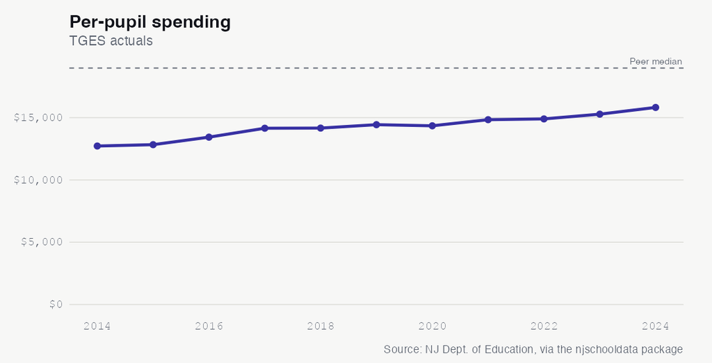

See the underlying data ›

No. 2 DEMOGRAPHICS

## In a Decade, Hamilton Flipped From Majority-White to 45% Hispanic

Hispanic enrollment share nearly doubled from 23.4% to 45.0% since 2015 as the white share fell from 51.4% to 31.2%.

Hamilton Township looks demographically different than it did a decade ago. In 2015, 51.4% of students were white and 23.4% were Hispanic. By 2026, those shares had crossed: Hispanic students made up 45.0% of enrollment and white students 31.2% — a 21.7-percentage-point rise for Hispanic students and a 20.3-point decline for white students over the same window.

The shift has been steady rather than sudden, ticking up almost every year, while the Black share held nearly flat (18.1% in 2015 to 16.6% in 2026) and the Asian and multiracial shares stayed small. This is a compositional change in who attends Hamilton’s schools, not a story about any one group leaving.

The transformation tracks alongside rising counts of multilingual learners, whose share grew from 2.4% to 10.6% over the same period. As Hispanic students approach an enrollment majority, how is the district adapting instruction, staffing, and family outreach to match who is in its classrooms today?

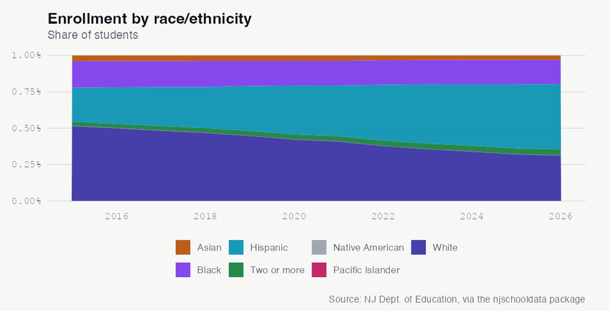

See the underlying data ›

No. 3 DEMOGRAPHICS

## Students Eligible for Free or Reduced Lunch Jumped From 42% to 57% in Just Three Years

After a decade of stability near 39%, Hamilton’s economic-need share surged from 41.9% in 2023 to 56.8% in 2026.

For most of the past decade, the share of Hamilton students qualifying for free or reduced-price lunch barely moved, holding between 38% and 42% from 2015 through 2023. Then it broke sharply upward: 41.9% in 2023, 48.2% in 2024, 54.3% in 2025, and 56.8% in 2026 — a roughly 15-point jump in three years that put a majority of Hamilton’s students in the economic-need category for the first time.

The count rose from 4,951 students in 2023 to 6,880 in 2026, nearly 2,000 more children. The rise coincides with a parallel climb in multilingual learners, whose share grew from 5.6% in 2023 to 10.6% in 2026.

A jump this size and this fast can reflect real shifts in family circumstances, changes in how eligibility is counted, or both. Whatever the mix, more than half of Hamilton’s students now come from economically disadvantaged households. Is the district’s budget — still near the bottom of its peer group on per-pupil spending — keeping pace with a student body whose needs are rising this quickly?

See the underlying data ›

No. 4 ACHIEVEMENT

## Hamilton’s Grade 3-8 Reading Proficiency Never Recovered From COVID — Still 9 Points Below 2019

NJSLA ELA proficiency fell from 46.5% in 2019 to 36.2% in 2022 and sat at just 37.4% by 2024.

On the state’s NJSLA tests for grades 3 through 8, Hamilton students were already losing ground before the pandemic — English language arts proficiency slipped from 48.6% in 2017 to 46.5% in 2019. Then COVID hit, and ELA proficiency dropped to 36.2% in 2022, a 10.3-point fall from 2019.

The recovery has been faint. ELA ticked up to 39.2% in 2023 before slipping again to 37.4% in 2024 — still roughly nine points below where it stood in 2019, with no clear upward trend three years past the disruption. Math tells a similar story: proficiency fell from 34.0% in 2019 to 23.2% in 2022 and reached only 25.1% by 2024, meaning about three in four students were not proficient in math.

These are the grades that feed Hamilton’s high schools, where the four-year graduation rate just dropped to 88.8%. With proficiency stalled well below pre-pandemic levels, what will it take for Hamilton’s elementary and middle grades to claw back the ground lost in 2020 and 2021?

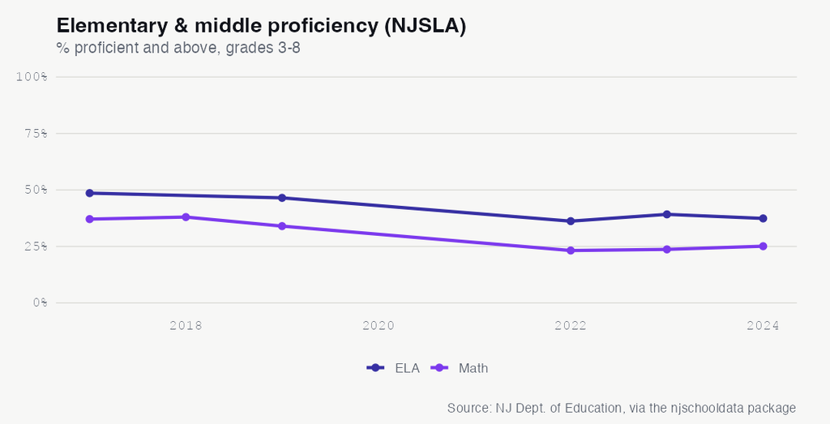

See the underlying data ›

No. 5 GRADUATION

## Hamilton’s Graduation Rate Slipped to 88.8% in 2025 — 10th Percentile Among 89 Peer Districts

After holding above 91% for five years, the four-year rate dropped to its lowest point in the record, well below the peer median of 95.4%.

Hamilton’s four-year graduation rate had been remarkably steady, ranging from 91.0% to 92.3% between 2020 and 2024. In 2025 it broke that pattern, falling to 88.8% — the lowest figure in the available record and a roughly 2.5-point drop in a single year.

The decline is more striking against Hamilton’s peers. Among the 89 districts in its District Factor Group, the median graduation rate is 95.4%, placing Hamilton’s 2025 result at just the 10th percentile of its group. The 2025 cohort numbered 1,000 students, meaning the gap between Hamilton and its typical peer represents dozens of additional graduates.

A single year is not yet a trend, but it is a clear break from a stable baseline. Was 2025 a one-time dip tied to a particular cohort, or the first sign that Hamilton’s graduation rate is drifting away from its peer group?

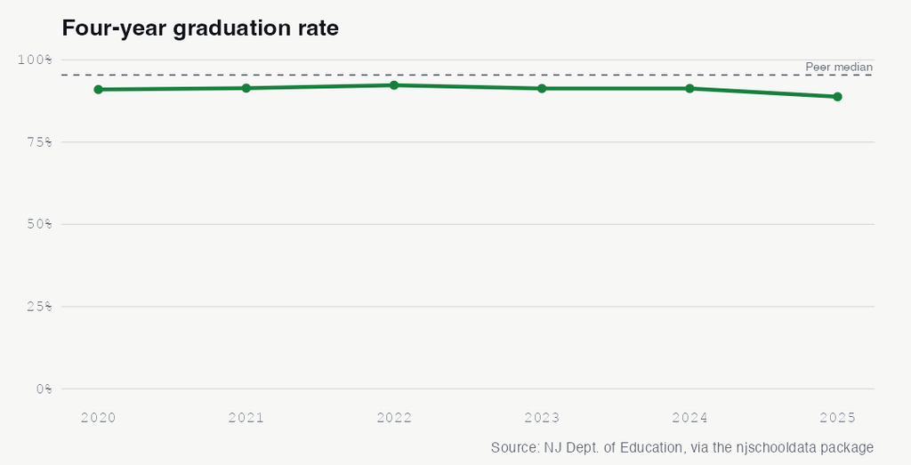

See the underlying data ›

No. 6 EQUITY

## 95% of Hamilton’s White Seniors Graduate — but Just 70% of Multilingual Learners Do

Hamilton’s 2025 graduation rate ranged from 95.5% for white students to 70.3% for multilingual learners, a 25-point spread.

Hamilton’s overall 88.8% graduation rate in 2025 masks wide differences across groups of students. White students graduated at 95.5% and Asian students at 90.0%, both above the district average. Below it sat students who are economically disadvantaged (86.4%), Black students (86.1%), and Hispanic students (85.2%) — the district’s largest racial group.

These gaps arrive as Hamilton’s multilingual-learner population is growing fast, from 2.4% of enrollment in 2015 to 10.6% in 2026. As that group expands, which supports will move its graduation rate toward the 95% Hamilton’s white students already reach?

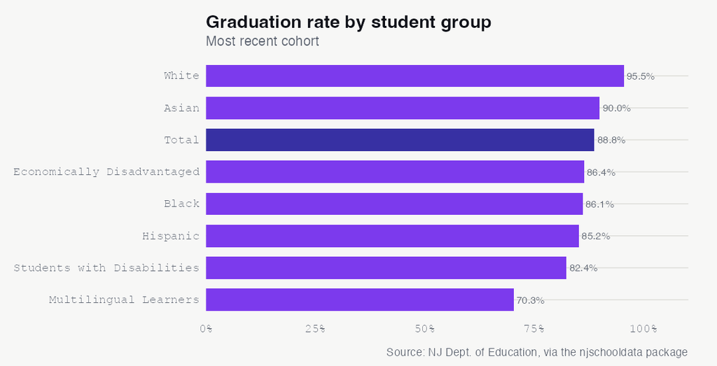

See the underlying data ›

No. 7 EQUITY

## Half of Hamilton’s White Students Read at Grade Level — Compared With 1 in 11 Students in Special Education

2024 NJSLA reading proficiency ranged from 50.6% for white students to 9.1% for students in special education.

On the 2024 NJSLA reading test for grades 3 through 8, proficiency varied enormously by group within Hamilton. White students reached 50.6% proficiency and Asian students 47.5%, both above the district’s 37.4% overall. Hispanic students (28.3%) and Black students (29.6%) — together a majority of Hamilton’s enrollment — landed well below that line, as did students who are economically disadvantaged (26.1%).

The lowest results belong to students with the most specialized needs. Students in special education reached 9.1% reading proficiency, multilingual learners 11.1%, and students classified as current multilingual learners just 1.2%. Put plainly, about half of white students met the reading bar, while roughly one in eleven students in special education did.

These are the same elementary and middle grades whose overall proficiency has stalled below pre-pandemic levels. With economically disadvantaged and multilingual populations both growing, how will Hamilton lift reading proficiency for the groups now furthest from grade level?

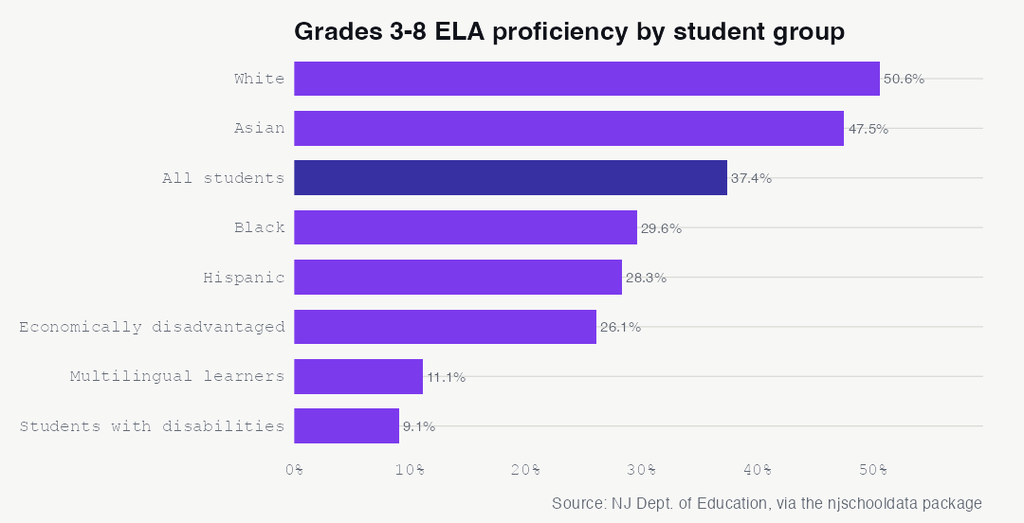

See the underlying data ›

No. 8 ATTENDANCE

## 1 in 7 Hamilton Students Was Chronically Absent in 2024 — Above the Peer Median and Pre-COVID Norm

Chronic absenteeism reached 15.2% in 2024, down from a 19.1% peak but still above the 11.3% peer median and the 12.4% pre-pandemic level.

Chronic absenteeism in Hamilton has not returned to its pre-pandemic footing. In 2019, 12.4% of students were chronically absent. The rate dropped to 9.7% in 2021 amid disrupted schooling, then spiked to 18.4% in 2022 and 19.1% in 2023 before easing to 15.2% in 2024.

That 2024 figure is an improvement over the peak, but it still leaves about one in seven Hamilton students missing enough school to be flagged chronically absent — and it sits above the 11.3% median for districts in Hamilton’s peer group, as well as above Hamilton’s own 12.4% pre-COVID baseline.

Chronic absence in the early and middle grades is closely tied to the reading and math proficiency that has stalled across Hamilton’s NJSLA results. With the rate trending down but not yet back to 2019, can Hamilton sustain the recovery and pull below its peer group’s median?

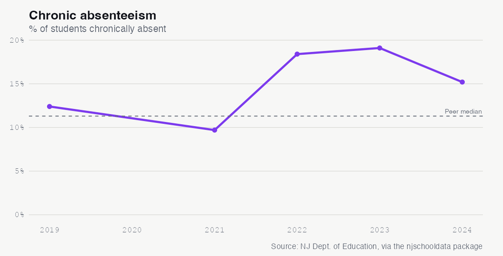

See the underlying data ›

No. 9 ENROLLMENT

## Hamilton’s Enrollment Recovered to 12,112 After Bottoming Out at 11,388 in the Pandemic

After dipping to an 11,388-student trough in 2021, enrollment rebounded to 12,194 by 2025 before easing slightly to 12,112 in 2026.

That leaves Hamilton with 330 more students than it had in 2015, a 2.8% increase across the period, and essentially flat through the COVID window itself (a gain of 82 students, or 0.7%, from 2019 to 2022).

Growing enrollment puts pressure on a district that still spends near the bottom of its peer group per pupil. As the student body keeps expanding and its needs rise, will Hamilton’s resources stretch to match a larger, higher-need school system?

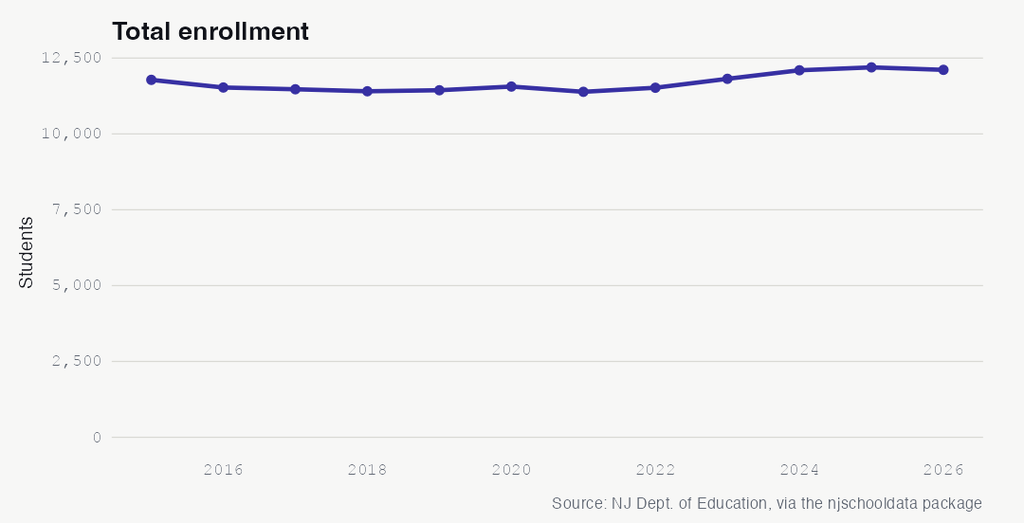

See the underlying data ›

No. 10 ACHIEVEMENT

## Hamilton’s NJGPA Math Proficiency Stuck Below 40% Even as Reading Holds Near 69%

On the high-school graduation-readiness test, 68.6% of Hamilton students were proficient in ELA in 2025 but only 38.5% in math.

Hamilton’s high schoolers post very different results in reading and math on the NJGPA, the state’s graduation-readiness assessment. ELA proficiency has been steady and strong, ranging from 66.7% in 2023 to 68.6% in 2025. Math has been weaker and bumpier: 39.3% in 2023, 32.2% in 2024, and 38.5% in 2025 — never crossing 40%.

The roughly 30-point gap between reading and math proficiency means a majority of Hamilton’s high schoolers clear the ELA bar while most fall short in math. The pattern echoes the district’s grades 3-8 NJSLA results, where math proficiency (25.1% in 2024) trails ELA (37.4%) at every level.

A persistent reading-math split that runs from elementary through high school points to a subject-specific challenge rather than a one-grade problem. What is driving Hamilton’s math results, and can the district lift them the way it has sustained reading?

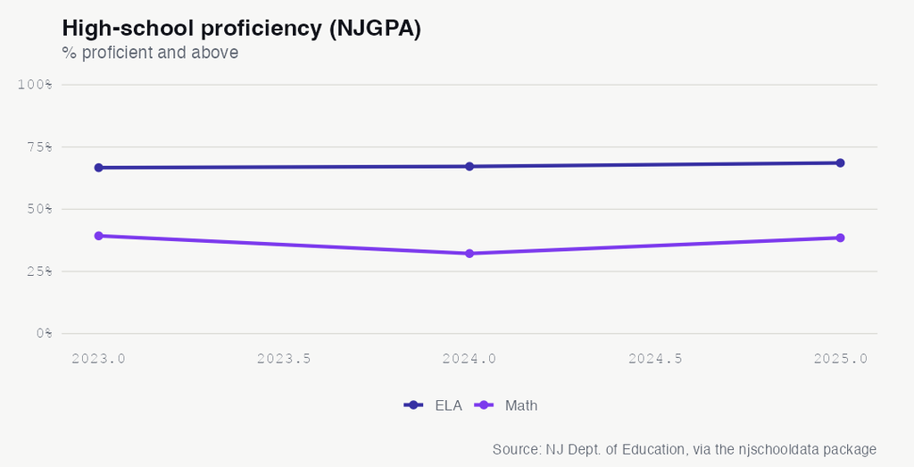

See the underlying data ›

## The Almanac

The full longitudinal record behind the stories above. Every number a reader can check.

### Enrollment (total)

| year | students | yoy | yoy_pct |
| --- | --- | --- | --- |
| 2015 | 11782 | NA | NA |
| 2016 | 11530 | -252 | -2.1 |
| 2017 | 11472 | -58 | -0.5 |
| 2018 | 11406 | -66 | -0.6 |
| 2019 | 11440 | 34 | 0.3 |
| 2020 | 11561 | 121 | 1.1 |
| 2021 | 11388 | -173 | -1.5 |
| 2022 | 11522 | 134 | 1.2 |
| 2023 | 11816 | 294 | 2.6 |
| 2024 | 12098 | 282 | 2.4 |
| 2025 | 12194 | 96 | 0.8 |
| 2026 | 12112 | -82 | -0.7 |

### Demographic share (%) by year

| end_year | white | black | hispanic | asian | native_american | pacific_islander | multiracial |
| --- | --- | --- | --- | --- | --- | --- | --- |
| 2015 | 51.4 | 18.1 | 23.4 | 4.1 | 0.1 | 0.1 | 2.8 |
| 2016 | 49.9 | 18 | 25.1 | 3.9 | 0.1 | 0.1 | 2.9 |
| 2017 | 48.3 | 17.8 | 26.9 | 3.9 | 0.1 | 0.2 | 2.9 |
| 2018 | 46.7 | 18 | 28.2 | 3.7 | 0.1 | 0.1 | 3.2 |
| 2019 | 44.7 | 17.2 | 31 | 3.8 | 0 | 0.1 | 3.3 |
| 2020 | 42.1 | 17 | 33.7 | 3.7 | 0.1 | 0.1 | 3.4 |
| 2021 | 40.8 | 16.9 | 34.8 | 3.8 | 0.1 | 0.1 | 3.6 |
| 2022 | 37.7 | 16.8 | 38.3 | 3.4 | 0 | 0.1 | 3.7 |
| 2023 | 35.5 | 16.7 | 40.7 | 3.2 | 0.1 | 0.1 | 3.8 |
| 2024 | 33.9 | 16.8 | 42.1 | 3.1 | 0 | 0.1 | 3.9 |
| 2025 | 32 | 16.9 | 44 | 3.1 | 0.1 | 0.1 | 4 |
| 2026 | 31.2 | 16.6 | 45 | 3 | 0.1 | 0.1 | 4 |

### Special populations (LEP, FRL)

| end_year | subgroup | students | pct |
| --- | --- | --- | --- |
| 2015 | lep | 278 | 2.4 |
| 2015 | free_reduced_lunch | 4530 | 38.4 |
| 2016 | lep | 260 | 2.3 |
| 2016 | free_reduced_lunch | 4547 | 39.4 |
| 2017 | lep | 264 | 2.3 |
| 2017 | free_reduced_lunch | 4530 | 39.5 |
| 2018 | lep | 365 | 3.2 |
| 2018 | free_reduced_lunch | 4484 | 39.3 |
| 2019 | lep | 492 | 4.3 |
| 2019 | free_reduced_lunch | 4422 | 38.6 |
| 2020 | lep | 659 | 5.7 |
| 2020 | free_reduced_lunch | 4532 | 39.2 |
| 2021 | lep | 604 | 5.3 |
| 2021 | free_reduced_lunch | 4657 | 40.9 |
| 2022 | lep | 588 | 5.1 |
| 2022 | free_reduced_lunch | 4793 | 41.6 |
| 2023 | lep | 662 | 5.6 |
| 2023 | free_reduced_lunch | 4951 | 41.9 |
| 2024 | lep | 859 | 7.1 |
| 2024 | free_reduced_lunch | 5831 | 48.2 |
| 2025 | lep | 1073 | 8.8 |
| 2025 | free_reduced_lunch | 6622 | 54.3 |
| 2026 | lep | 1284 | 10.6 |
| 2026 | free_reduced_lunch | 6880 | 56.8 |

### Graduation rate 4yr (total)

| year | grad_rate | cohort |
| --- | --- | --- |
| 2020 | 91 | 932 |
| 2021 | 91.4 | 972 |
| 2022 | 92.3 | 972 |
| 2023 | 91.3 | 983 |
| 2024 | 91.3 | 992 |
| 2025 | 88.8 | 1000 |

### Graduation by subgroup (2025)

| subgroup | grad_rate | cohort |
| --- | --- | --- |
| white | 95.5 | 335 |
| asian | 90.0 | 20 |
| male | 88.9 | 541 |
| total | 88.8 | 1000 |
| female | 88.7 | 459 |
| economically disadvantaged | 86.4 | 594 |
| black | 86.1 | 187 |
| hispanic | 85.2 | 427 |
| students with disabilities | 82.4 | 182 |
| students experiencing homelessness | 81.8 | 11 |
| multiracial | 80.6 | 31 |
| multilingual learners | 70.3 | 111 |
| american indian | NA | NA |
| migrant students | NA | NA |
| military-connected students | NA | NA |
| non-binary/undesignated gender | NA | NA |
| students in foster care | NA | NA |

### NJGPA high-school proficiency (% proficient+)

| year | test | prof_above | valid |
| --- | --- | --- | --- |
| 2023 | ela | 66.7 | 929 |
| 2023 | math | 39.3 | 937 |
| 2024 | ela | 67.2 | 930 |
| 2024 | math | 32.2 | 930 |
| 2025 | ela | 68.6 | 955 |
| 2025 | math | 38.5 | 962 |

### NJGPA ELA by subgroup (2025)

[output not shown]

### NJSLA grades 3-8 proficiency (% proficient+, enrollment-weighted across grades)

| testing_year | test_name | prof |
| --- | --- | --- |
| 2017 | ela | 48.6 |
| 2017 | math | 37.1 |
| 2018 | math | 38.0 |
| 2019 | ela | 46.5 |
| 2019 | math | 34.0 |
| 2022 | ela | 36.2 |
| 2022 | math | 23.2 |
| 2023 | ela | 39.2 |
| 2023 | math | 23.7 |
| 2024 | ela | 37.4 |
| 2024 | math | 25.1 |

### NJSLA ELA proficiency by subgroup (2024, grades 3-8)

| subgroup | prof |
| --- | --- |
| white | 50.6 |
| non_ed | 48.0 |
| asian | 47.5 |
| female | 43.7 |
| other | 42.9 |
| total_population | 37.4 |
| male | 31.3 |
| black | 29.6 |
| hispanic | 28.3 |
| lep_former | 27.2 |
| ed | 26.1 |
| FORMER - ML | 18.1 |
| lep_current_former | 16.9 |
| MULTILINGUAL LEARNERS | 11.1 |
| sped_accomodations | 10.0 |
| special_education | 9.1 |
| CURRENT - ML | 1.2 |
| lep_current | 0.0 |

### Chronic absenteeism (% chronically absent)

| year | chronic_pct |
| --- | --- |
| 2019 | 12.4 |
| 2021 | 9.7 |
| 2022 | 18.4 |
| 2023 | 19.1 |
| 2024 | 15.2 |

### Disciplinary removals

[output not shown]

### Police notifications (incident counts)

| year | violence | weapons | vandalism | substances | hib | other |
| --- | --- | --- | --- | --- | --- | --- |
| 2019 | 75 | 11 | 8 | 41 | 19 | 37 |
| 2020 | 54 | 7 | 10 | 25 | 14 | 32 |
| 2021 | 1 | 3 | 1 | 5 | 3 | 3 |
| 2022 | 78 | 14 | 13 | 24 | 6 | 32 |
| 2023 | 67 | 19 | 15 | 43 | 17 | 32 |
| 2024 | 47 | 9 | 13 | 56 | 14 | 30 |

### HIB (harassment/intimidation/bullying) investigations

| end_year | alleged | confirmed |
| --- | --- | --- |
| 2019 | 105 | 117 |
| 2020 | 73 | 99 |
| 2021 | 17 | 32 |
| 2022 | 78 | 115 |
| 2023 | 141 | 126 |
| 2024 | 93 | 90 |

### SAT participation (% of grade)

| year | sat_part | state_sat |
| --- | --- | --- |
| 2018 | 75.7 | 72.2 |
| 2019 | 72.8 | 72.1 |
| 2020 | 79.1 | 71.1 |
| 2021 | 33.1 | 45.4 |
| 2022 | 47.5 | 60.8 |
| 2023 | 53.7 | 61.9 |
| 2024 | 49.6 | 62.7 |

### AP/IB & dual enrollment (% of students)

| year | apib_coursework | apib_exam | ap3_ib4 | state_ap3_ib4 | dual |
| --- | --- | --- | --- | --- | --- |
| 2018 | 47.4 | 19.3 | 11.8 | 20.5 | 6 |
| 2019 | 45.5 | 40.1 | 14 | 20.7 | 10.4 |
| 2020 | 40 | 36.5 | 22.4 | 22.8 | 13.8 |
| 2021 | 37.1 | 33.6 | 16 | 17.9 | 10.4 |
| 2022 | 32 | 30.5 | 16.2 | 19.9 | 8.8 |
| 2023 | 31.6 | 31.3 | 15 | 21.3 | 16 |
| 2024 | 35.8 | 34.9 | 17.5 | 23 | 13.1 |

### Special education (raw rows; inspect for classification rate)

| end_year | district_id |
| --- | --- |
| 2024 | 1950 |

### Per-pupil spending (TGES actuals)

| year | per_pupil | rank | ade |
| --- | --- | --- | --- |
| 2014 | 12722 | 22 | 12065 |
| 2015 | 12830 | 20 | 11908 |
| 2016 | 13433 | 29 | 11673 |
| 2017 | 14150 | 33 | 11599 |
| 2018 | 14161 | 26 | 11419 |
| 2019 | 14435 | 18 | 11424 |
| 2020 | 14345 | 16 | 11550 |
| 2021 | 14835 | 18 | 11361 |
| 2022 | 14898 | 6 | 11545 |
| 2023 | 15278 | 5 | 11804 |
| 2024 | 15818 | 6 | 12083 |

### Spending composition shares (2025)

| classroom_share | support_services_share | administration_share | plant_ops_share | food_service_share | extracurricular_share | equipment_share |
| --- | --- | --- | --- | --- | --- | --- |
| 59.1 | 16 | 10.8 | 12.2 | NA | 1.7 | 0 |

### Staffing ratios

| end_year | student_teacher_district | student_admin_district | student_counselor_district | student_nurse_district |
| --- | --- | --- | --- | --- |
| 2024 | 12:1 | 185:1 | 234:1 | 488:1 |

Back to top